# Airbnb Final Project

### Regularized Regression Results

Knowing our results for the linear regression model, we know we might see pretty similar in our elastic net models! Let’s take a look at our autoplots:

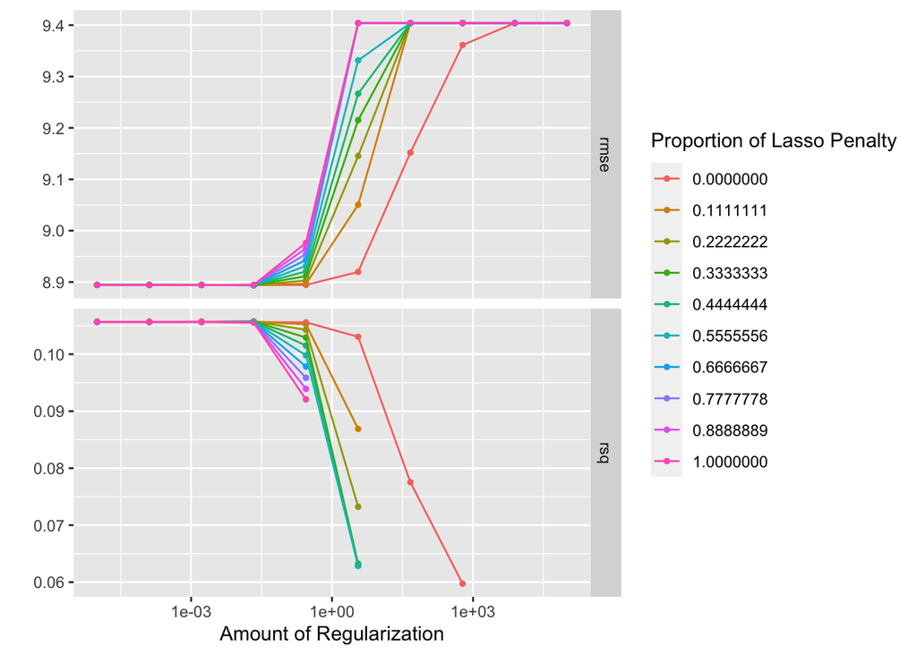

```r
autoplot(regreg_results)
```

The models did about the same as our linear regression model! The elastic net model did better with lower values of both regularization and lasso penalty with rmse and rsq. Let’s look at which specific values gave us the best rsq and rmse:

```r
regreg <- regreg_results %>%
  collect_metrics() %>%
  subset(.metric == "rmse") %>%
  arrange(mean) %>%
  slice(1)

regreg <- rbind(regreg, regreg_results %>%
  collect_metrics() %>%
  subset(.metric == "rsq") %>%
  arrange(desc(mean)) %>%
  slice(1))

regreg
```

```
## # A tibble: 2 × 8
##   penalty mixture .metric .estimator  mean     n std_err .config
##     <dbl>   <dbl> <chr>   <chr>      <dbl> <int>   <dbl> <chr>
## 1  0.0215   0.333 rmse    standard   8.89      3 0.108   Preprocessor1_Model034
## 2  0.0215   0.222 rsq     standard   0.106     3 0.00217 Preprocessor1_Model024
```

Pretty similar to the linear regression! Hopefully we will be able to see some improvements in the boosted tree models.

### Boosted Trees Results

Here the models saw a substantial jump in run time. It took a little under an hour to fit all the boosted tree models to the data. Let’s hope to see some improvement, and take a look at the autoplot:

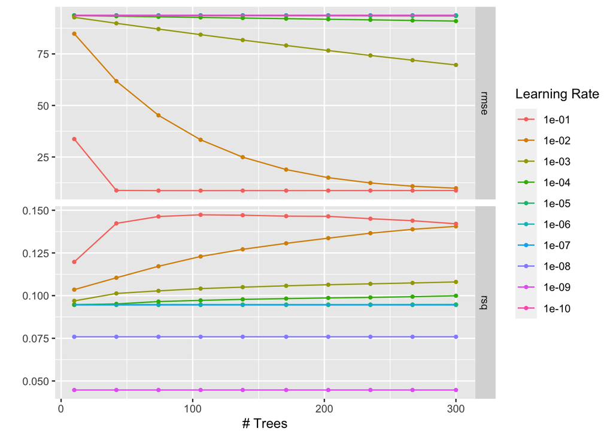

```r
autoplot(bt_results)
```

```r
bt <- bt_results %>%
  collect_metrics() %>%
  subset(.metric == "rmse") %>%
  arrange(mean) %>%
  slice(1)

bt <- rbind(bt, bt_results %>%
  collect_metrics() %>%
  subset(.metric == "rsq") %>%
  arrange(desc(mean)) %>%
  slice(1))

bt
```

```
## # A tibble: 2 × 8
##   trees learn_rate .metric .estimator  mean     n std_err .config
##   <int>      <dbl> <chr>   <chr>      <dbl> <int>   <dbl> <chr>
## 1   106        0.1 rmse    standard   8.69      3 0.0885  Preprocessor1_Model094
## 2   106        0.1 rsq     standard   0.147     3 0.00255 Preprocessor1_Model094
```

Here we can see that the same exact model gave us the best rmse and rsq. It had 106 trees and a learning rate of 0.1! We see a decrease in rmse by about 0.21 points and an increase in rsq by 4%! Let’s see if our random forest can do better.

### Random Forest Results

The random forest model had by far the longest run time. It had crashed my laptop after almost 24 hours of tuning, and took about nine and a half to run on a different laptop. After all that, let’s take a look at an autoplot of the results:

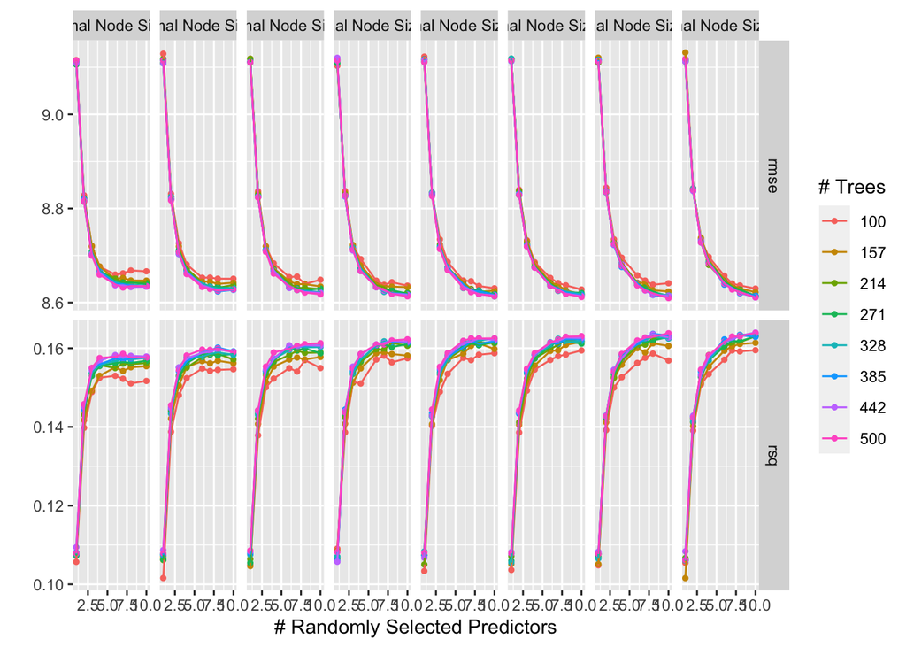

```r
autoplot(rf_results)
```

Though they look pretty similar, we can see that models with more trees did better than the ones with less trees, and that more random predictors and more minimal node sizes also gave us better values. Like before, let’s look at the specific values of the best models:

```r
rf <- rf_results %>%
  collect_metrics() %>%
  subset(.metric == "rmse") %>%
  arrange(mean) %>%
  slice(1)

rf <- rbind(rf, rf_results %>%
  collect_metrics() %>%
  subset(.metric == "rsq") %>%
  arrange(desc(mean)) %>%
  slice(1))

rf
```

```
## # A tibble: 2 × 9
##    mtry trees min_n .metric .estimator  mean     n std_err .config
##   <int> <int> <int> <chr>   <chr>      <dbl> <int>   <dbl> <chr>
## 1    10   500    17 rmse    standard   8.61      3 0.0968  Preprocessor1_Model5…
## 2    10   442    20 rsq     standard   0.164     3 0.00182 Preprocessor1_Model4…
```

We saw a slight increase in our model this time as well! Our rmse went down by 0.08 and our rsq went up by 1.6%. Though still pretty low, it is nice to see our rmse and rsq improve!

We can also take a look at the variable importance plot for our rmse to see which variables were split on most often:

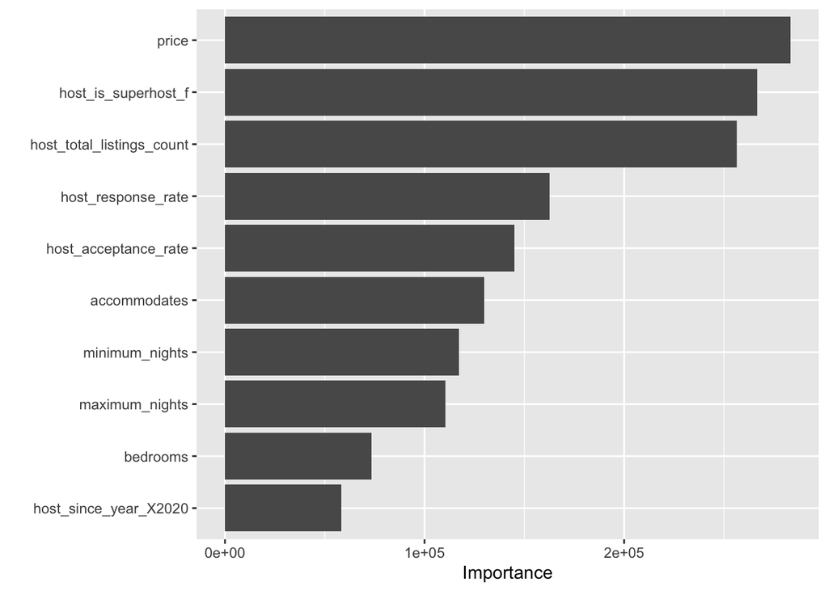

```r
load('results/rf_vip')
rf_vip
```

The price of the Airbnb, whether the host was a superhost, and the total amount of listings a host has, seem to be the most decisive variables! It makes sense that the price of the Airbnb and a higher amount of experience of the host would ensure a better stay for the occupants.

Now, having run all of our models, we will choose the best one and fit it to our testing set!

### Choosing a Model

Let’s compare our models side by side to choose which one we will fit to our testing set. First let’s look at rsme:

```r
rmses <- c(lm %>% subset(.metric == "rmse") %>% select(mean),
           regreg %>% subset(.metric == "rmse") %>% select(mean),
           bt %>% subset(.metric == "rmse") %>% select(mean),
           rf %>% subset(.metric == "rmse") %>% select(mean))

models <- c("Linear Regression",
            "Regularized Regression",
            "Boosted Tree",
            "Random Forest")

results <- tibble(models = models, rmse = rmses)

results %>%
  unnest(cols = rmse) %>%
  arrange(rmse)
```

```
## # A tibble: 4 × 2
##   models                  rmse
##   <chr>                  <dbl>
## 1 Random Forest           8.61
## 2 Boosted Tree            8.69
## 3 Regularized Regression  8.89
## 4 Linear Regression       8.89
```

Here we can see that the Random Forest model performed the best with the lowest rmse! Let’s see if it is any different for the rsq:

```r
rsqs <- c(lm %>% subset(.metric == "rsq") %>% select(mean),
           regreg %>% subset(.metric == "rsq") %>% select(mean),
           bt %>% subset(.metric == "rsq") %>% select(mean),
           rf %>% subset(.metric == "rsq") %>% select(mean))

models <- c("Linear Regression",
            "Regularized Regression",
            "Boosted Tree",
            "Random Forest")

results <- tibble(models = models, rsq = rsqs)

results %>%
  unnest(cols = rsq) %>%
  arrange(desc(rsq))
```

```
## # A tibble: 4 × 2
##   models                   rsq
##   <chr>                  <dbl>
## 1 Random Forest          0.164
## 2 Boosted Tree           0.147
## 3 Regularized Regression 0.106
## 4 Linear Regression      0.106
```

We can see here that the Random Forest had the best results yet again!

### Fitting to the Testing Set

Now that we’ve decided on a model, we will fit our random forest to the testing data. To do that, we will finalize our workflow, and finally fit the model!

```r
final_rf_wf <- forest_wf %>%
  finalize_workflow(select_best(rf_results, "rmse"))   #finalizing workflow

final_fit <- fit(final_rf_wf, data = abnb_te)         #fitting to test set
```

Now that the data is fit, we can use it to predict values for our listings! Let’s cross our fingers and hope for the best!

```r
preds <- augment(final_fit, new_data = abnb_te) %>%
  select(review_scores_rating, starts_with(".pred"))

preds %>% head()
```

```
## # A tibble: 6 × 2
##   review_scores_rating .pred
##                  <int> <dbl>
## 1                   80  88.2
## 2                   20  75.8
## 3                   93  95.7
## 4                   86  91.0
## 5                   85  90.1
## 6                   80  88.7
```

Looking at these values, we can see that there is a little bit of a difference between the actual values and our predicted ones. However, the model is able to still distinguish between which reviews should be rated higher and which ones should be rated lower!

For the grand reveal let’s look at our rmse and rsq:

```r
final_metrics <- rmse(preds, truth = review_scores_rating, estimate = .pred) %>%
  rbind(rsq(preds, truth = review_scores_rating, estimate = .pred))

final_metrics
```

```
## # A tibble: 2 × 3
##   .metric .estimator .estimate
##   <chr>   <chr>          <dbl>
## 1 rmse    standard       6.19
## 2 rsq     standard       0.707
```

Let’s look at the listings that had the biggest differences between actual values and predictions:

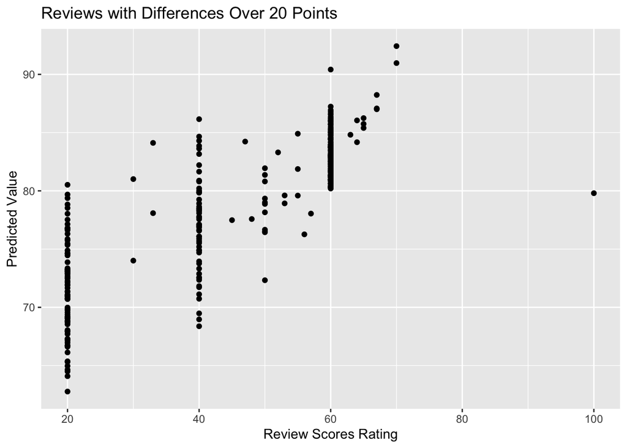

```r
augment(final_fit, new_data = abnb_te) %>%
  mutate(diff = abs(review_scores_rating - .pred)) %>%
  filter(diff >= 20) %>%
  select(review_scores_rating, .pred) %>%
  ggplot(aes(x = review_scores_rating, y = .pred)) +
  geom_point(alpha = 1) +
  labs(x = "Review Scores Rating",
       y = "Predicted Value",
       title = "Reviews with Differences Over 20 Points")
```

We can tell by this graph that our model does a poor job of predicting lower rated Airbnb review score ratings. Looking more closely, we can see that many of the values fall on multiples of 20, specifically 20, 40, and 60. This is likely because the specific Airbnbs received minimal ratings, which is why our model does a poor job of predicting them. In the future, if there is a possibility of adding review count to the dataset, it may increase our metrics even further.